# Risk Factor Analysis

## Outcome Variable

**Outcome Variable:** ever_wasted

## Predictor Variables

**Intervention Variable:** mbmi

**Adjustment Set:**

- arm
- W_mage
- meducyrs
- feducyrs
- hhwealth_quart
- W_nchldlt5
- brthmon
- W_parity
- delta_W_mage
- delta_meducyrs
- delta_feducyrs
- delta_hhwealth_quart
- delta_W_nchldlt5
- delta_brthmon
- delta_W_parity

## Stratifying Variables

The analysis was stratified on these variable(s):

- agecat
- studyid
- country

## Data Summary

| agecat | studyid | country | mbmi | ever_wasted | n_cell | n |
| --- | --- | --- | --- | --- | --- | --- |
| 0-24 months | iLiNS-Zinc | BURKINA FASO | Normal weight | 0 | 2161 | 3217 |
| 0-24 months | iLiNS-Zinc | BURKINA FASO | Normal weight | 1 | 602 | 3217 |
| 0-24 months | iLiNS-Zinc | BURKINA FASO | Underweight | 0 | 323 | 3217 |
| 0-24 months | iLiNS-Zinc | BURKINA FASO | Underweight | 1 | 131 | 3217 |
| 0-24 months | JiVitA-3 | BANGLADESH | Normal weight | 0 | 12433 | 26836 |
| 0-24 months | JiVitA-3 | BANGLADESH | Normal weight | 1 | 4127 | 26836 |
| 0-24 months | JiVitA-3 | BANGLADESH | Underweight | 0 | 7478 | 26836 |
| 0-24 months | JiVitA-3 | BANGLADESH | Underweight | 1 | 2798 | 26836 |
| 0-24 months | LCNI-5 | MALAWI | Normal weight | 0 | 651 | 837 |
| 0-24 months | LCNI-5 | MALAWI | Normal weight | 1 | 41 | 837 |
| 0-24 months | LCNI-5 | MALAWI | Underweight | 0 | 120 | 837 |
| 0-24 months | LCNI-5 | MALAWI | Underweight | 1 | 25 | 837 |
| 0-24 months | MAL-ED | BANGLADESH | Normal weight | 0 | 154 | 254 |
| 0-24 months | MAL-ED | BANGLADESH | Normal weight | 1 | 68 | 254 |
| 0-24 months | MAL-ED | BANGLADESH | Underweight | 0 | 15 | 254 |
| 0-24 months | MAL-ED | BANGLADESH | Underweight | 1 | 17 | 254 |
| 0-24 months | MAL-ED | BRAZIL | Normal weight | 0 | 194 | 221 |
| 0-24 months | MAL-ED | BRAZIL | Normal weight | 1 | 17 | 221 |
| 0-24 months | MAL-ED | BRAZIL | Underweight | 0 | 8 | 221 |
| 0-24 months | MAL-ED | BRAZIL | Underweight | 1 | 2 | 221 |
| 0-24 months | MAL-ED | INDIA | Normal weight | 0 | 105 | 242 |
| 0-24 months | MAL-ED | INDIA | Normal weight | 1 | 88 | 242 |
| 0-24 months | MAL-ED | INDIA | Underweight | 0 | 20 | 242 |
| 0-24 months | MAL-ED | INDIA | Underweight | 1 | 29 | 242 |
| 0-24 months | MAL-ED | NEPAL | Normal weight | 0 | 164 | 238 |
| 0-24 months | MAL-ED | NEPAL | Normal weight | 1 | 74 | 238 |
| 0-24 months | MAL-ED | NEPAL | Underweight | 0 | 0 | 238 |
| 0-24 months | MAL-ED | NEPAL | Underweight | 1 | 0 | 238 |
| 0-24 months | MAL-ED | PERU | Normal weight | 0 | 260 | 290 |
| 0-24 months | MAL-ED | PERU | Normal weight | 1 | 25 | 290 |

[output cut: 170 more lines]

The following strata were considered:

- agecat: 0-24 months, studyid: iLiNS-Zinc, country: BURKINA FASO
- agecat: 0-24 months, studyid: JiVitA-3, country: BANGLADESH
- agecat: 0-24 months, studyid: LCNI-5, country: MALAWI
- agecat: 0-24 months, studyid: MAL-ED, country: BANGLADESH
- agecat: 0-24 months, studyid: MAL-ED, country: BRAZIL
- agecat: 0-24 months, studyid: MAL-ED, country: INDIA
- agecat: 0-24 months, studyid: MAL-ED, country: NEPAL
- agecat: 0-24 months, studyid: MAL-ED, country: PERU
- agecat: 0-24 months, studyid: MAL-ED, country: SOUTH AFRICA
- agecat: 0-24 months, studyid: MAL-ED, country: TANZANIA, UNITED REPUBLIC OF
- agecat: 0-24 months, studyid: NIH-Birth, country: BANGLADESH
- agecat: 0-24 months, studyid: NIH-Crypto, country: BANGLADESH
- agecat: 0-24 months, studyid: PROBIT, country: BELARUS
- agecat: 0-24 months, studyid: PROVIDE, country: BANGLADESH
- agecat: 0-24 months, studyid: SAS-CompFeed, country: INDIA
- agecat: 0-24 months, studyid: TanzaniaChild2, country: TANZANIA, UNITED REPUBLIC OF
- agecat: 0-24 months, studyid: ZVITAMBO, country: ZIMBABWE
- agecat: 0-6 months, studyid: JiVitA-3, country: BANGLADESH
- agecat: 0-6 months, studyid: LCNI-5, country: MALAWI
- agecat: 0-6 months, studyid: MAL-ED, country: BANGLADESH
- agecat: 0-6 months, studyid: MAL-ED, country: BRAZIL
- agecat: 0-6 months, studyid: MAL-ED, country: INDIA
- agecat: 0-6 months, studyid: MAL-ED, country: NEPAL
- agecat: 0-6 months, studyid: MAL-ED, country: PERU
- agecat: 0-6 months, studyid: MAL-ED, country: SOUTH AFRICA
- agecat: 0-6 months, studyid: MAL-ED, country: TANZANIA, UNITED REPUBLIC OF
- agecat: 0-6 months, studyid: NIH-Birth, country: BANGLADESH
- agecat: 0-6 months, studyid: NIH-Crypto, country: BANGLADESH
- agecat: 0-6 months, studyid: PROBIT, country: BELARUS
- agecat: 0-6 months, studyid: PROVIDE, country: BANGLADESH
- agecat: 0-6 months, studyid: SAS-CompFeed, country: INDIA
- agecat: 0-6 months, studyid: TanzaniaChild2, country: TANZANIA, UNITED REPUBLIC OF
- agecat: 0-6 months, studyid: ZVITAMBO, country: ZIMBABWE
- agecat: 6-24 months, studyid: iLiNS-Zinc, country: BURKINA FASO
- agecat: 6-24 months, studyid: JiVitA-3, country: BANGLADESH
- agecat: 6-24 months, studyid: LCNI-5, country: MALAWI
- agecat: 6-24 months, studyid: MAL-ED, country: BANGLADESH
- agecat: 6-24 months, studyid: MAL-ED, country: BRAZIL
- agecat: 6-24 months, studyid: MAL-ED, country: INDIA
- agecat: 6-24 months, studyid: MAL-ED, country: NEPAL
- agecat: 6-24 months, studyid: MAL-ED, country: PERU
- agecat: 6-24 months, studyid: MAL-ED, country: SOUTH AFRICA
- agecat: 6-24 months, studyid: MAL-ED, country: TANZANIA, UNITED REPUBLIC OF
- agecat: 6-24 months, studyid: NIH-Birth, country: BANGLADESH
- agecat: 6-24 months, studyid: NIH-Crypto, country: BANGLADESH
- agecat: 6-24 months, studyid: PROBIT, country: BELARUS
- agecat: 6-24 months, studyid: PROVIDE, country: BANGLADESH
- agecat: 6-24 months, studyid: SAS-CompFeed, country: INDIA
- agecat: 6-24 months, studyid: TanzaniaChild2, country: TANZANIA, UNITED REPUBLIC OF
- agecat: 6-24 months, studyid: ZVITAMBO, country: ZIMBABWE

### Dropped Strata

Some strata were dropped due to rare outcomes:

- agecat: 0-24 months, studyid: MAL-ED, country: BRAZIL
- agecat: 0-24 months, studyid: MAL-ED, country: NEPAL
- agecat: 0-24 months, studyid: MAL-ED, country: PERU
- agecat: 0-24 months, studyid: MAL-ED, country: SOUTH AFRICA
- agecat: 0-24 months, studyid: MAL-ED, country: TANZANIA, UNITED REPUBLIC OF
- agecat: 0-6 months, studyid: LCNI-5, country: MALAWI
- agecat: 0-6 months, studyid: MAL-ED, country: BRAZIL
- agecat: 0-6 months, studyid: MAL-ED, country: NEPAL
- agecat: 0-6 months, studyid: MAL-ED, country: PERU
- agecat: 0-6 months, studyid: MAL-ED, country: SOUTH AFRICA
- agecat: 0-6 months, studyid: MAL-ED, country: TANZANIA, UNITED REPUBLIC OF
- agecat: 6-24 months, studyid: MAL-ED, country: BRAZIL
- agecat: 6-24 months, studyid: MAL-ED, country: NEPAL
- agecat: 6-24 months, studyid: MAL-ED, country: PERU
- agecat: 6-24 months, studyid: MAL-ED, country: SOUTH AFRICA
- agecat: 6-24 months, studyid: MAL-ED, country: TANZANIA, UNITED REPUBLIC OF

## Methods Detail

We're interested in the causal parameters $E[Y_a]$ for all values of $a \in \mathcal{A}$. These parameters represent the mean outcome if, possibly contrary to fact, we intervened to set all units to have $A=a$. Under the randomization and positivity assumptions, these are identified by the statistical parameters $\psi_a=E_W[E_{Y|A,W}(Y|A=a,W)]$. In addition, we're interested in the mean of $Y$, $E[Y]$ under no intervention (the observed mean). We will estimate these parameters by using SuperLearner to fit the relevant likelihood factors -- $E_{Y|A,W}(Y|A=a,W)$ and $p(A=a|W)$, and then updating our likelihood fit using a joint TMLE.

For unadjusted analyses ($W=\{\}$), initial likelihoods were estimated using Lrnr_glm to estimate the simple $E(Y|A)$ and Lrnr_mean to estimate $p(A)$. For adjusted analyses, a small library containing Lrnr_glmnet, Lrnr_xgboost, and Lrnr_mean was used.

Having estimated these parameters, we will then use the delta method to estimate relative risks and attributable risks relative to a prespecified baseline level of $A$.

# Results Detail

## Results Plots

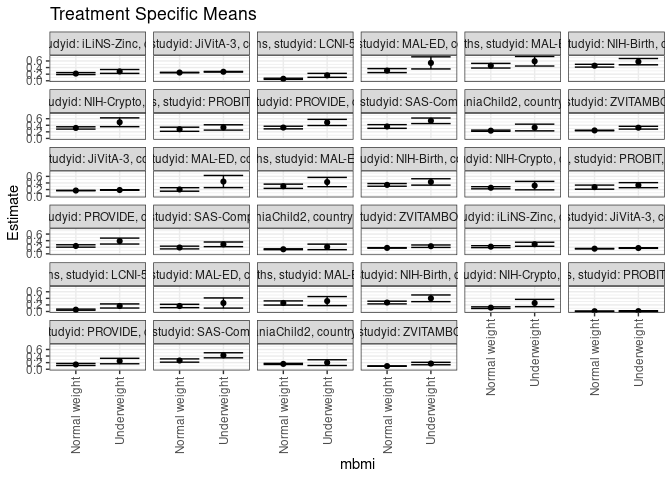

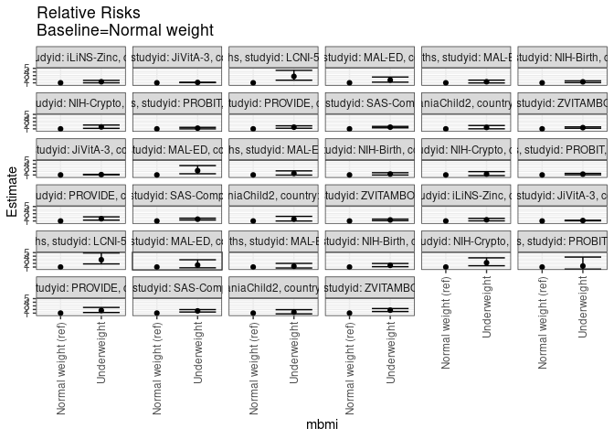

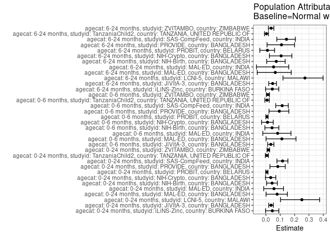

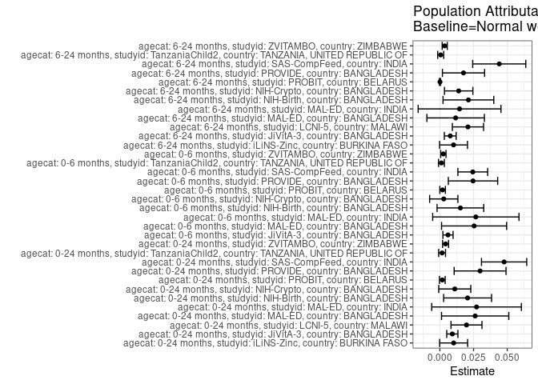

## Results Table

### Parameter: TSM

| agecat | studyid | country | intervention_level | baseline_level | estimate | ci_lower | ci_upper |
| --- | --- | --- | --- | --- | --- | --- | --- |
| 0-24 months | iLiNS-Zinc | BURKINA FASO | Normal weight | NA | 0.2176412 | 0.1880735 | 0.2472089 |
| 0-24 months | iLiNS-Zinc | BURKINA FASO | Underweight | NA | 0.2820784 | 0.2232777 | 0.3408791 |
| 0-24 months | JiVitA-3 | BANGLADESH | Normal weight | NA | 0.2488069 | 0.2411679 | 0.2564458 |
| 0-24 months | JiVitA-3 | BANGLADESH | Underweight | NA | 0.2728160 | 0.2633701 | 0.2822618 |
| 0-24 months | LCNI-5 | MALAWI | Normal weight | NA | 0.0590987 | 0.0414530 | 0.0767444 |
| 0-24 months | LCNI-5 | MALAWI | Underweight | NA | 0.1637364 | 0.1035981 | 0.2238748 |
| 0-24 months | MAL-ED | BANGLADESH | Normal weight | NA | 0.3084472 | 0.2477239 | 0.3691706 |
| 0-24 months | MAL-ED | BANGLADESH | Underweight | NA | 0.5423914 | 0.3588097 | 0.7259731 |
| 0-24 months | MAL-ED | INDIA | Normal weight | NA | 0.4562438 | 0.3858525 | 0.5266350 |
| 0-24 months | MAL-ED | INDIA | Underweight | NA | 0.5916020 | 0.4472910 | 0.7359129 |
| 0-24 months | NIH-Birth | BANGLADESH | Normal weight | NA | 0.4569878 | 0.4140969 | 0.4998787 |
| 0-24 months | NIH-Birth | BANGLADESH | Underweight | NA | 0.5796186 | 0.4841148 | 0.6751225 |
| 0-24 months | NIH-Crypto | BANGLADESH | Normal weight | NA | 0.3187490 | 0.2836887 | 0.3538093 |
| 0-24 months | NIH-Crypto | BANGLADESH | Underweight | NA | 0.4913751 | 0.3577768 | 0.6249733 |
| 0-24 months | PROBIT | BELARUS | Normal weight | NA | 0.2789093 | 0.2166858 | 0.3411328 |
| 0-24 months | PROBIT | BELARUS | Underweight | NA | 0.3338725 | 0.2537552 | 0.4139897 |
| 0-24 months | PROVIDE | BANGLADESH | Normal weight | NA | 0.3303989 | 0.2907204 | 0.3700773 |
| 0-24 months | PROVIDE | BANGLADESH | Underweight | NA | 0.4861373 | 0.3928289 | 0.5794457 |
| 0-24 months | SAS-CompFeed | INDIA | Normal weight | NA | 0.3631256 | 0.3072146 | 0.4190367 |
| 0-24 months | SAS-CompFeed | INDIA | Underweight | NA | 0.5362040 | 0.4523152 | 0.6200928 |
| 0-24 months | TanzaniaChild2 | TANZANIA, UNITED REPUBLIC OF | Normal weight | NA | 0.2354590 | 0.2179679 | 0.2529502 |
| 0-24 months | TanzaniaChild2 | TANZANIA, UNITED REPUBLIC OF | Underweight | NA | 0.3313133 | 0.2296872 | 0.4329394 |
| 0-24 months | ZVITAMBO | ZIMBABWE | Normal weight | NA | 0.2428821 | 0.2341498 | 0.2516144 |
| 0-24 months | ZVITAMBO | ZIMBABWE | Underweight | NA | 0.3261700 | 0.2836692 | 0.3686709 |
| 0-6 months | JiVitA-3 | BANGLADESH | Normal weight | NA | 0.1701951 | 0.1632787 | 0.1771115 |
| 0-6 months | JiVitA-3 | BANGLADESH | Underweight | NA | 0.1858796 | 0.1777388 | 0.1940204 |
| 0-6 months | MAL-ED | BANGLADESH | Normal weight | NA | 0.2029432 | 0.1498911 | 0.2559952 |
| 0-6 months | MAL-ED | BANGLADESH | Underweight | NA | 0.4435621 | 0.2594123 | 0.6277119 |
| 0-6 months | MAL-ED | INDIA | Normal weight | NA | 0.2997508 | 0.2348748 | 0.3646267 |
| 0-6 months | MAL-ED | INDIA | Underweight | NA | 0.4272393 | 0.2858159 | 0.5686626 |
| 0-6 months | NIH-Birth | BANGLADESH | Normal weight | NA | 0.3416729 | 0.3007915 | 0.3825543 |
| 0-6 months | NIH-Birth | BANGLADESH | Underweight | NA | 0.4304596 | 0.3340312 | 0.5268881 |
| 0-6 months | NIH-Crypto | BANGLADESH | Normal weight | NA | 0.2540683 | 0.2212971 | 0.2868395 |
| 0-6 months | NIH-Crypto | BANGLADESH | Underweight | NA | 0.3197735 | 0.1918234 | 0.4477237 |
| 0-6 months | PROBIT | BELARUS | Normal weight | NA | 0.2729424 | 0.2104762 | 0.3354086 |
| 0-6 months | PROBIT | BELARUS | Underweight | NA | 0.3333887 | 0.2565329 | 0.4102444 |
| 0-6 months | PROVIDE | BANGLADESH | Normal weight | NA | 0.2384912 | 0.2023464 | 0.2746359 |
| 0-6 months | PROVIDE | BANGLADESH | Underweight | NA | 0.3878250 | 0.2980572 | 0.4775927 |
| 0-6 months | SAS-CompFeed | INDIA | Normal weight | NA | 0.1910618 | 0.1494389 | 0.2326847 |
| 0-6 months | SAS-CompFeed | INDIA | Underweight | NA | 0.2880964 | 0.2171024 | 0.3590904 |
| 0-6 months | TanzaniaChild2 | TANZANIA, UNITED REPUBLIC OF | Normal weight | NA | 0.1391417 | 0.1248886 | 0.1533949 |
| 0-6 months | TanzaniaChild2 | TANZANIA, UNITED REPUBLIC OF | Underweight | NA | 0.2105263 | 0.1264891 | 0.2945635 |
| 0-6 months | ZVITAMBO | ZIMBABWE | Normal weight | NA | 0.1800032 | 0.1721673 | 0.1878391 |
| 0-6 months | ZVITAMBO | ZIMBABWE | Underweight | NA | 0.2318533 | 0.1940715 | 0.2696352 |
| 6-24 months | iLiNS-Zinc | BURKINA FASO | Normal weight | NA | 0.2177097 | 0.1880844 | 0.2473351 |
| 6-24 months | iLiNS-Zinc | BURKINA FASO | Underweight | NA | 0.2906862 | 0.2295085 | 0.3518639 |
| 6-24 months | JiVitA-3 | BANGLADESH | Normal weight | NA | 0.1560630 | 0.1487856 | 0.1633405 |
| 6-24 months | JiVitA-3 | BANGLADESH | Underweight | NA | 0.1759899 | 0.1663014 | 0.1856784 |
| 6-24 months | LCNI-5 | MALAWI | Normal weight | NA | 0.0557168 | 0.0384700 | 0.0729636 |
| 6-24 months | LCNI-5 | MALAWI | Underweight | NA | 0.1681642 | 0.1058909 | 0.2304376 |
| 6-24 months | MAL-ED | BANGLADESH | Normal weight | NA | 0.1674641 | 0.1167366 | 0.2181917 |
| 6-24 months | MAL-ED | BANGLADESH | Underweight | NA | 0.2580645 | 0.1037094 | 0.4124197 |
| 6-24 months | MAL-ED | INDIA | Normal weight | NA | 0.2588874 | 0.1957007 | 0.3220740 |
| 6-24 months | MAL-ED | INDIA | Underweight | NA | 0.3166114 | 0.1796811 | 0.4535418 |
| 6-24 months | NIH-Birth | BANGLADESH | Normal weight | NA | 0.2721823 | 0.2310067 | 0.3133579 |
| 6-24 months | NIH-Birth | BANGLADESH | Underweight | NA | 0.4014451 | 0.3001096 | 0.5027805 |
| 6-24 months | NIH-Crypto | BANGLADESH | Normal weight | NA | 0.1175525 | 0.0930077 | 0.1420973 |
| 6-24 months | NIH-Crypto | BANGLADESH | Underweight | NA | 0.2580333 | 0.1472101 | 0.3688566 |
| 6-24 months | PROBIT | BELARUS | Normal weight | NA | 0.0089414 | 0.0044666 | 0.0134163 |
| 6-24 months | PROBIT | BELARUS | Underweight | NA | 0.0114723 | -0.0012562 | 0.0242007 |
| 6-24 months | PROVIDE | BANGLADESH | Normal weight | NA | 0.1437014 | 0.1132376 | 0.1741652 |
| 6-24 months | PROVIDE | BANGLADESH | Underweight | NA | 0.2478322 | 0.1651698 | 0.3304946 |
| 6-24 months | SAS-CompFeed | INDIA | Normal weight | NA | 0.2636975 | 0.2139379 | 0.3134572 |
| 6-24 months | SAS-CompFeed | INDIA | Underweight | NA | 0.4227097 | 0.3456562 | 0.4997632 |
| 6-24 months | TanzaniaChild2 | TANZANIA, UNITED REPUBLIC OF | Normal weight | NA | 0.1606591 | 0.1441588 | 0.1771595 |
| 6-24 months | TanzaniaChild2 | TANZANIA, UNITED REPUBLIC OF | Underweight | NA | 0.2000000 | 0.1128772 | 0.2871228 |
| 6-24 months | ZVITAMBO | ZIMBABWE | Normal weight | NA | 0.0950480 | 0.0886714 | 0.1014246 |
| 6-24 months | ZVITAMBO | ZIMBABWE | Underweight | NA | 0.1719282 | 0.1352024 | 0.2086541 |

### Parameter: E(Y)

| agecat | studyid | country | intervention_level | baseline_level | estimate | ci_lower | ci_upper |
| --- | --- | --- | --- | --- | --- | --- | --- |
| 0-24 months | iLiNS-Zinc | BURKINA FASO | NA | NA | 0.2278520 | 0.2008644 | 0.2548397 |
| 0-24 months | JiVitA-3 | BANGLADESH | NA | NA | 0.2580489 | 0.2515797 | 0.2645181 |
| 0-24 months | LCNI-5 | MALAWI | NA | NA | 0.0788530 | 0.0605839 | 0.0971222 |
| 0-24 months | MAL-ED | BANGLADESH | NA | NA | 0.3346457 | 0.2765014 | 0.3927899 |
| 0-24 months | MAL-ED | INDIA | NA | NA | 0.4834711 | 0.4203794 | 0.5465628 |
| 0-24 months | NIH-Birth | BANGLADESH | NA | NA | 0.4775641 | 0.4383415 | 0.5167867 |
| 0-24 months | NIH-Crypto | BANGLADESH | NA | NA | 0.3298013 | 0.2962438 | 0.3633589 |
| 0-24 months | PROBIT | BELARUS | NA | NA | 0.2807401 | 0.2185990 | 0.3428812 |
| 0-24 months | PROVIDE | BANGLADESH | NA | NA | 0.3602392 | 0.3238339 | 0.3966444 |
| 0-24 months | SAS-CompFeed | INDIA | NA | NA | 0.4107914 | 0.3512139 | 0.4703688 |
| 0-24 months | TanzaniaChild2 | TANZANIA, UNITED REPUBLIC OF | NA | NA | 0.2371002 | 0.2198828 | 0.2543177 |
| 0-24 months | ZVITAMBO | ZIMBABWE | NA | NA | 0.2471165 | 0.2385749 | 0.2556580 |
| 0-6 months | JiVitA-3 | BANGLADESH | NA | NA | 0.1762220 | 0.1706009 | 0.1818431 |
| 0-6 months | MAL-ED | BANGLADESH | NA | NA | 0.2283465 | 0.1766220 | 0.2800709 |
| 0-6 months | MAL-ED | INDIA | NA | NA | 0.3264463 | 0.2672449 | 0.3856476 |
| 0-6 months | NIH-Birth | BANGLADESH | NA | NA | 0.3569132 | 0.3192325 | 0.3945938 |
| 0-6 months | NIH-Crypto | BANGLADESH | NA | NA | 0.2569536 | 0.2257649 | 0.2881424 |
| 0-6 months | PROBIT | BELARUS | NA | NA | 0.2749854 | 0.2126043 | 0.3373666 |
| 0-6 months | PROVIDE | BANGLADESH | NA | NA | 0.2630792 | 0.2296894 | 0.2964690 |
| 0-6 months | SAS-CompFeed | INDIA | NA | NA | 0.2154736 | 0.1691818 | 0.2617655 |
| 0-6 months | TanzaniaChild2 | TANZANIA, UNITED REPUBLIC OF | NA | NA | 0.1402985 | 0.1262390 | 0.1543580 |
| 0-6 months | ZVITAMBO | ZIMBABWE | NA | NA | 0.1825820 | 0.1749172 | 0.1902467 |
| 6-24 months | iLiNS-Zinc | BURKINA FASO | NA | NA | 0.2278520 | 0.2008644 | 0.2548397 |
| 6-24 months | JiVitA-3 | BANGLADESH | NA | NA | 0.1637481 | 0.1576337 | 0.1698625 |
| 6-24 months | LCNI-5 | MALAWI | NA | NA | 0.0765492 | 0.0583736 | 0.0947248 |
| 6-24 months | MAL-ED | BANGLADESH | NA | NA | 0.1791667 | 0.1305478 | 0.2277856 |
| 6-24 months | MAL-ED | INDIA | NA | NA | 0.2735043 | 0.2162683 | 0.3307402 |
| 6-24 months | NIH-Birth | BANGLADESH | NA | NA | 0.2933579 | 0.2549918 | 0.3317241 |
| 6-24 months | NIH-Crypto | BANGLADESH | NA | NA | 0.1315068 | 0.1069744 | 0.1560393 |
| 6-24 months | PROBIT | BELARUS | NA | NA | 0.0090379 | 0.0045686 | 0.0135072 |
| 6-24 months | PROVIDE | BANGLADESH | NA | NA | 0.1612378 | 0.1321259 | 0.1903497 |
| 6-24 months | SAS-CompFeed | INDIA | NA | NA | 0.3077525 | 0.2591695 | 0.3563356 |
| 6-24 months | TanzaniaChild2 | TANZANIA, UNITED REPUBLIC OF | NA | NA | 0.1612576 | 0.1450216 | 0.1774936 |
| 6-24 months | ZVITAMBO | ZIMBABWE | NA | NA | 0.0986391 | 0.0923357 | 0.1049424 |

### Parameter: RR

| agecat | studyid | country | intervention_level | baseline_level | estimate | ci_lower | ci_upper |
| --- | --- | --- | --- | --- | --- | --- | --- |
| 0-24 months | iLiNS-Zinc | BURKINA FASO | Normal weight | Normal weight | 1.000000 | 1.0000000 | 1.000000 |
| 0-24 months | iLiNS-Zinc | BURKINA FASO | Underweight | Normal weight | 1.296071 | 1.0027483 | 1.675195 |
| 0-24 months | JiVitA-3 | BANGLADESH | Normal weight | Normal weight | 1.000000 | 1.0000000 | 1.000000 |
| 0-24 months | JiVitA-3 | BANGLADESH | Underweight | Normal weight | 1.096497 | 1.0520383 | 1.142834 |
| 0-24 months | LCNI-5 | MALAWI | Normal weight | Normal weight | 1.000000 | 1.0000000 | 1.000000 |
| 0-24 months | LCNI-5 | MALAWI | Underweight | Normal weight | 2.770559 | 1.7266455 | 4.445613 |
| 0-24 months | MAL-ED | BANGLADESH | Normal weight | Normal weight | 1.000000 | 1.0000000 | 1.000000 |
| 0-24 months | MAL-ED | BANGLADESH | Underweight | Normal weight | 1.758458 | 1.1878798 | 2.603103 |
| 0-24 months | MAL-ED | INDIA | Normal weight | Normal weight | 1.000000 | 1.0000000 | 1.000000 |
| 0-24 months | MAL-ED | INDIA | Underweight | Normal weight | 1.296679 | 0.9689986 | 1.735170 |
| 0-24 months | NIH-Birth | BANGLADESH | Normal weight | Normal weight | 1.000000 | 1.0000000 | 1.000000 |
| 0-24 months | NIH-Birth | BANGLADESH | Underweight | Normal weight | 1.268346 | 1.0491859 | 1.533286 |
| 0-24 months | NIH-Crypto | BANGLADESH | Normal weight | Normal weight | 1.000000 | 1.0000000 | 1.000000 |
| 0-24 months | NIH-Crypto | BANGLADESH | Underweight | Normal weight | 1.541574 | 1.1496347 | 2.067134 |
| 0-24 months | PROBIT | BELARUS | Normal weight | Normal weight | 1.000000 | 1.0000000 | 1.000000 |
| 0-24 months | PROBIT | BELARUS | Underweight | Normal weight | 1.197065 | 1.0068345 | 1.423237 |
| 0-24 months | PROVIDE | BANGLADESH | Normal weight | Normal weight | 1.000000 | 1.0000000 | 1.000000 |
| 0-24 months | PROVIDE | BANGLADESH | Underweight | Normal weight | 1.471365 | 1.1730927 | 1.845476 |
| 0-24 months | SAS-CompFeed | INDIA | Normal weight | Normal weight | 1.000000 | 1.0000000 | 1.000000 |
| 0-24 months | SAS-CompFeed | INDIA | Underweight | Normal weight | 1.476635 | 1.2941174 | 1.684894 |
| 0-24 months | TanzaniaChild2 | TANZANIA, UNITED REPUBLIC OF | Normal weight | Normal weight | 1.000000 | 1.0000000 | 1.000000 |
| 0-24 months | TanzaniaChild2 | TANZANIA, UNITED REPUBLIC OF | Underweight | Normal weight | 1.407095 | 1.0261717 | 1.929421 |
| 0-24 months | ZVITAMBO | ZIMBABWE | Normal weight | Normal weight | 1.000000 | 1.0000000 | 1.000000 |
| 0-24 months | ZVITAMBO | ZIMBABWE | Underweight | Normal weight | 1.342915 | 1.1731221 | 1.537283 |
| 0-6 months | JiVitA-3 | BANGLADESH | Normal weight | Normal weight | 1.000000 | 1.0000000 | 1.000000 |
| 0-6 months | JiVitA-3 | BANGLADESH | Underweight | Normal weight | 1.092156 | 1.0333942 | 1.154259 |
| 0-6 months | MAL-ED | BANGLADESH | Normal weight | Normal weight | 1.000000 | 1.0000000 | 1.000000 |
| 0-6 months | MAL-ED | BANGLADESH | Underweight | Normal weight | 2.185646 | 1.3357481 | 3.576311 |
| 0-6 months | MAL-ED | INDIA | Normal weight | Normal weight | 1.000000 | 1.0000000 | 1.000000 |
| 0-6 months | MAL-ED | INDIA | Underweight | Normal weight | 1.425315 | 0.9588313 | 2.118749 |
| 0-6 months | NIH-Birth | BANGLADESH | Normal weight | Normal weight | 1.000000 | 1.0000000 | 1.000000 |
| 0-6 months | NIH-Birth | BANGLADESH | Underweight | Normal weight | 1.259859 | 0.9780612 | 1.622848 |
| 0-6 months | NIH-Crypto | BANGLADESH | Normal weight | Normal weight | 1.000000 | 1.0000000 | 1.000000 |
| 0-6 months | NIH-Crypto | BANGLADESH | Underweight | Normal weight | 1.258613 | 0.8264609 | 1.916734 |
| 0-6 months | PROBIT | BELARUS | Normal weight | Normal weight | 1.000000 | 1.0000000 | 1.000000 |
| 0-6 months | PROBIT | BELARUS | Underweight | Normal weight | 1.221461 | 1.0387846 | 1.436263 |
| 0-6 months | PROVIDE | BANGLADESH | Normal weight | Normal weight | 1.000000 | 1.0000000 | 1.000000 |
| 0-6 months | PROVIDE | BANGLADESH | Underweight | Normal weight | 1.626161 | 1.2332598 | 2.144235 |
| 0-6 months | SAS-CompFeed | INDIA | Normal weight | Normal weight | 1.000000 | 1.0000000 | 1.000000 |
| 0-6 months | SAS-CompFeed | INDIA | Underweight | Normal weight | 1.507870 | 1.2776398 | 1.779588 |
| 0-6 months | TanzaniaChild2 | TANZANIA, UNITED REPUBLIC OF | Normal weight | Normal weight | 1.000000 | 1.0000000 | 1.000000 |
| 0-6 months | TanzaniaChild2 | TANZANIA, UNITED REPUBLIC OF | Underweight | Normal weight | 1.513035 | 1.0020087 | 2.284685 |
| 0-6 months | ZVITAMBO | ZIMBABWE | Normal weight | Normal weight | 1.000000 | 1.0000000 | 1.000000 |
| 0-6 months | ZVITAMBO | ZIMBABWE | Underweight | Normal weight | 1.288051 | 1.0881383 | 1.524692 |
| 6-24 months | iLiNS-Zinc | BURKINA FASO | Normal weight | Normal weight | 1.000000 | 1.0000000 | 1.000000 |
| 6-24 months | iLiNS-Zinc | BURKINA FASO | Underweight | Normal weight | 1.335201 | 1.0332322 | 1.725421 |
| 6-24 months | JiVitA-3 | BANGLADESH | Normal weight | Normal weight | 1.000000 | 1.0000000 | 1.000000 |
| 6-24 months | JiVitA-3 | BANGLADESH | Underweight | Normal weight | 1.127685 | 1.0535262 | 1.207063 |
| 6-24 months | LCNI-5 | MALAWI | Normal weight | Normal weight | 1.000000 | 1.0000000 | 1.000000 |
| 6-24 months | LCNI-5 | MALAWI | Underweight | Normal weight | 3.018198 | 1.8667224 | 4.879954 |
| 6-24 months | MAL-ED | BANGLADESH | Normal weight | Normal weight | 1.000000 | 1.0000000 | 1.000000 |
| 6-24 months | MAL-ED | BANGLADESH | Underweight | Normal weight | 1.541014 | 0.7881894 | 3.012884 |
| 6-24 months | MAL-ED | INDIA | Normal weight | Normal weight | 1.000000 | 1.0000000 | 1.000000 |
| 6-24 months | MAL-ED | INDIA | Underweight | Normal weight | 1.222970 | 0.7428578 | 2.013380 |
| 6-24 months | NIH-Birth | BANGLADESH | Normal weight | Normal weight | 1.000000 | 1.0000000 | 1.000000 |
| 6-24 months | NIH-Birth | BANGLADESH | Underweight | Normal weight | 1.474913 | 1.0993343 | 1.978804 |
| 6-24 months | NIH-Crypto | BANGLADESH | Normal weight | Normal weight | 1.000000 | 1.0000000 | 1.000000 |
| 6-24 months | NIH-Crypto | BANGLADESH | Underweight | Normal weight | 2.195048 | 1.3611983 | 3.539701 |
| 6-24 months | PROBIT | BELARUS | Normal weight | Normal weight | 1.000000 | 1.0000000 | 1.000000 |
| 6-24 months | PROBIT | BELARUS | Underweight | Normal weight | 1.283048 | 0.4377605 | 3.760530 |
| 6-24 months | PROVIDE | BANGLADESH | Normal weight | Normal weight | 1.000000 | 1.0000000 | 1.000000 |
| 6-24 months | PROVIDE | BANGLADESH | Underweight | Normal weight | 1.724633 | 1.1617838 | 2.560166 |
| 6-24 months | SAS-CompFeed | INDIA | Normal weight | Normal weight | 1.000000 | 1.0000000 | 1.000000 |
| 6-24 months | SAS-CompFeed | INDIA | Underweight | Normal weight | 1.603010 | 1.3019817 | 1.973638 |
| 6-24 months | TanzaniaChild2 | TANZANIA, UNITED REPUBLIC OF | Normal weight | Normal weight | 1.000000 | 1.0000000 | 1.000000 |
| 6-24 months | TanzaniaChild2 | TANZANIA, UNITED REPUBLIC OF | Underweight | Normal weight | 1.244872 | 0.7957064 | 1.947585 |
| 6-24 months | ZVITAMBO | ZIMBABWE | Normal weight | Normal weight | 1.000000 | 1.0000000 | 1.000000 |
| 6-24 months | ZVITAMBO | ZIMBABWE | Underweight | Normal weight | 1.808857 | 1.4459806 | 2.262799 |

### Parameter: PAR

| agecat | studyid | country | intervention_level | baseline_level | estimate | ci_lower | ci_upper |
| --- | --- | --- | --- | --- | --- | --- | --- |
| 0-24 months | iLiNS-Zinc | BURKINA FASO | Normal weight | NA | 0.0102108 | -0.0001660 | 0.0205876 |
| 0-24 months | JiVitA-3 | BANGLADESH | Normal weight | NA | 0.0092420 | 0.0050987 | 0.0133853 |
| 0-24 months | LCNI-5 | MALAWI | Normal weight | NA | 0.0197543 | 0.0082627 | 0.0312459 |
| 0-24 months | MAL-ED | BANGLADESH | Normal weight | NA | 0.0261985 | 0.0012372 | 0.0511598 |
| 0-24 months | MAL-ED | INDIA | Normal weight | NA | 0.0272273 | -0.0060433 | 0.0604979 |
| 0-24 months | NIH-Birth | BANGLADESH | Normal weight | NA | 0.0205763 | 0.0027953 | 0.0383574 |
| 0-24 months | NIH-Crypto | BANGLADESH | Normal weight | NA | 0.0110523 | -0.0008325 | 0.0229371 |
| 0-24 months | PROBIT | BELARUS | Normal weight | NA | 0.0018308 | -0.0002748 | 0.0039364 |
| 0-24 months | PROVIDE | BANGLADESH | Normal weight | NA | 0.0298403 | 0.0106004 | 0.0490802 |
| 0-24 months | SAS-CompFeed | INDIA | Normal weight | NA | 0.0476657 | 0.0308812 | 0.0644503 |
| 0-24 months | TanzaniaChild2 | TANZANIA, UNITED REPUBLIC OF | Normal weight | NA | 0.0016412 | -0.0008985 | 0.0041809 |
| 0-24 months | ZVITAMBO | ZIMBABWE | Normal weight | NA | 0.0042344 | 0.0020111 | 0.0064576 |
| 0-6 months | JiVitA-3 | BANGLADESH | Normal weight | NA | 0.0060269 | 0.0022515 | 0.0098023 |
| 0-6 months | MAL-ED | BANGLADESH | Normal weight | NA | 0.0254033 | 0.0012589 | 0.0495476 |
| 0-6 months | MAL-ED | INDIA | Normal weight | NA | 0.0266955 | -0.0053233 | 0.0587143 |
| 0-6 months | NIH-Birth | BANGLADESH | Normal weight | NA | 0.0152403 | -0.0020728 | 0.0325533 |
| 0-6 months | NIH-Crypto | BANGLADESH | Normal weight | NA | 0.0028854 | -0.0075983 | 0.0133691 |
| 0-6 months | PROBIT | BELARUS | Normal weight | NA | 0.0020430 | -0.0000194 | 0.0041054 |
| 0-6 months | PROVIDE | BANGLADESH | Normal weight | NA | 0.0245881 | 0.0062858 | 0.0428903 |
| 0-6 months | SAS-CompFeed | INDIA | Normal weight | NA | 0.0244118 | 0.0133678 | 0.0354558 |
| 0-6 months | TanzaniaChild2 | TANZANIA, UNITED REPUBLIC OF | Normal weight | NA | 0.0011568 | -0.0010052 | 0.0033187 |
| 0-6 months | ZVITAMBO | ZIMBABWE | Normal weight | NA | 0.0025788 | 0.0006036 | 0.0045539 |
| 6-24 months | iLiNS-Zinc | BURKINA FASO | Normal weight | NA | 0.0101423 | -0.0001960 | 0.0204806 |
| 6-24 months | JiVitA-3 | BANGLADESH | Normal weight | NA | 0.0076851 | 0.0033128 | 0.0120573 |
| 6-24 months | LCNI-5 | MALAWI | Normal weight | NA | 0.0208324 | 0.0092600 | 0.0324048 |
| 6-24 months | MAL-ED | BANGLADESH | Normal weight | NA | 0.0117026 | -0.0096347 | 0.0330398 |
| 6-24 months | MAL-ED | INDIA | Normal weight | NA | 0.0146169 | -0.0161117 | 0.0453454 |
| 6-24 months | NIH-Birth | BANGLADESH | Normal weight | NA | 0.0211757 | 0.0023435 | 0.0400079 |
| 6-24 months | NIH-Crypto | BANGLADESH | Normal weight | NA | 0.0139544 | 0.0034193 | 0.0244894 |
| 6-24 months | PROBIT | BELARUS | Normal weight | NA | 0.0000965 | -0.0003675 | 0.0005605 |
| 6-24 months | PROVIDE | BANGLADESH | Normal weight | NA | 0.0175364 | 0.0018821 | 0.0331907 |
| 6-24 months | SAS-CompFeed | INDIA | Normal weight | NA | 0.0440550 | 0.0243570 | 0.0637531 |
| 6-24 months | TanzaniaChild2 | TANZANIA, UNITED REPUBLIC OF | Normal weight | NA | 0.0005985 | -0.0016285 | 0.0028255 |
| 6-24 months | ZVITAMBO | ZIMBABWE | Normal weight | NA | 0.0035911 | 0.0017081 | 0.0054740 |

### Parameter: PAF

| agecat | studyid | country | intervention_level | baseline_level | estimate | ci_lower | ci_upper |
| --- | --- | --- | --- | --- | --- | --- | --- |
| 0-24 months | iLiNS-Zinc | BURKINA FASO | Normal weight | NA | 0.0448134 | -0.0025311 | 0.0899221 |
| 0-24 months | JiVitA-3 | BANGLADESH | Normal weight | NA | 0.0358150 | 0.0196100 | 0.0517520 |
| 0-24 months | LCNI-5 | MALAWI | Normal weight | NA | 0.2505210 | 0.1018922 | 0.3745530 |
| 0-24 months | MAL-ED | BANGLADESH | Normal weight | NA | 0.0782872 | 0.0008595 | 0.1497147 |
| 0-24 months | MAL-ED | INDIA | Normal weight | NA | 0.0563163 | -0.0152434 | 0.1228321 |
| 0-24 months | NIH-Birth | BANGLADESH | Normal weight | NA | 0.0430860 | 0.0049842 | 0.0797288 |
| 0-24 months | NIH-Crypto | BANGLADESH | Normal weight | NA | 0.0335120 | -0.0032027 | 0.0688831 |
| 0-24 months | PROBIT | BELARUS | Normal weight | NA | 0.0065212 | -0.0011777 | 0.0141610 |
| 0-24 months | PROVIDE | BANGLADESH | Normal weight | NA | 0.0828347 | 0.0279123 | 0.1346540 |
| 0-24 months | SAS-CompFeed | INDIA | Normal weight | NA | 0.1160340 | 0.0768798 | 0.1535274 |
| 0-24 months | TanzaniaChild2 | TANZANIA, UNITED REPUBLIC OF | Normal weight | NA | 0.0069219 | -0.0038773 | 0.0176048 |
| 0-24 months | ZVITAMBO | ZIMBABWE | Normal weight | NA | 0.0171350 | 0.0081034 | 0.0260845 |
| 0-6 months | JiVitA-3 | BANGLADESH | Normal weight | NA | 0.0342005 | 0.0124566 | 0.0554657 |
| 0-6 months | MAL-ED | BANGLADESH | Normal weight | NA | 0.1112488 | 0.0006384 | 0.2096168 |
| 0-6 months | MAL-ED | INDIA | Normal weight | NA | 0.0817761 | -0.0215866 | 0.1746808 |
| 0-6 months | NIH-Birth | BANGLADESH | Normal weight | NA | 0.0427002 | -0.0071023 | 0.0900399 |
| 0-6 months | NIH-Crypto | BANGLADESH | Normal weight | NA | 0.0112292 | -0.0304291 | 0.0512032 |
| 0-6 months | PROBIT | BELARUS | Normal weight | NA | 0.0074294 | -0.0003285 | 0.0151272 |
| 0-6 months | PROVIDE | BANGLADESH | Normal weight | NA | 0.0934626 | 0.0215661 | 0.1600760 |
| 0-6 months | SAS-CompFeed | INDIA | Normal weight | NA | 0.1132936 | 0.0683724 | 0.1560488 |
| 0-6 months | TanzaniaChild2 | TANZANIA, UNITED REPUBLIC OF | Normal weight | NA | 0.0082450 | -0.0073186 | 0.0235682 |
| 0-6 months | ZVITAMBO | ZIMBABWE | Normal weight | NA | 0.0141238 | 0.0032545 | 0.0248746 |
| 6-24 months | iLiNS-Zinc | BURKINA FASO | Normal weight | NA | 0.0445126 | -0.0026913 | 0.0894943 |
| 6-24 months | JiVitA-3 | BANGLADESH | Normal weight | NA | 0.0469323 | 0.0199139 | 0.0732058 |
| 6-24 months | LCNI-5 | MALAWI | Normal weight | NA | 0.2721445 | 0.1191554 | 0.3985617 |
| 6-24 months | MAL-ED | BANGLADESH | Normal weight | NA | 0.0653166 | -0.0608054 | 0.1764436 |
| 6-24 months | MAL-ED | INDIA | Normal weight | NA | 0.0534430 | -0.0656596 | 0.1592341 |
| 6-24 months | NIH-Birth | BANGLADESH | Normal weight | NA | 0.0721837 | 0.0058903 | 0.1340563 |
| 6-24 months | NIH-Crypto | BANGLADESH | Normal weight | NA | 0.1061113 | 0.0242704 | 0.1810876 |
| 6-24 months | PROBIT | BELARUS | Normal weight | NA | 0.0106745 | -0.0420841 | 0.0607620 |
| 6-24 months | PROVIDE | BANGLADESH | Normal weight | NA | 0.1087610 | 0.0079379 | 0.1993375 |
| 6-24 months | SAS-CompFeed | INDIA | Normal weight | NA | 0.1431508 | 0.0758637 | 0.2055386 |
| 6-24 months | TanzaniaChild2 | TANZANIA, UNITED REPUBLIC OF | Normal weight | NA | 0.0037114 | -0.0102192 | 0.0174499 |
| 6-24 months | ZVITAMBO | ZIMBABWE | Normal weight | NA | 0.0364061 | 0.0172439 | 0.0551947 |